# Researching on stochastic volatility of Tesla stock price in 2019

# 4 POMP model

## 4.1 Model description

Following the model representation of Breto, we propose a model,

$Y_n$ = exp{$H_n$/2}$\epsilon_n$

$H_n$ = $\mu_h$(1 - $\phi$) + $\phi$$H_{n-1}$ + $\beta_{n-1}$$R_n$exp{-$H_{n-1}$/2} + $\omega_n$

$G_n$ = $G_{n-1}$ + $\nu_n$

where $\beta_n$ = $Y_n$$\sigma_{\eta}$$\sqrt{1 - \phi^2}$,{$\epsilon_n$} is an iid N(0,1) sequence, {$\nu_n$} is an iid N(0,$\sigma_{\eta}^2$) sequence, and {$\omega_n$} is an iid N(0,$\sigma_{\omega}^2$) sequcence.

Here, $H_n$ is the log volatility.

We use the state variable $X_n$ = ($G_n$, $H_n$, $Y_n$) and model the measurement process as a perfect observation of the $Y_n$ component of the state space.

## 4.2 Building a POMP model

Firstly, we construct the POMP model as following.

```r
# Building a POMP model

require(pomp)
tsla_statenames <- c("H","G","Y_state")
tsla_rp_names <- c("sigma_nu","mu_h","phi","sigma_eta")
tsla_ivp_names <- c("G_0","H_0")
tsla_paramnames <- c(tsla_rp_names,tsla_ivp_names)

rproc1 <- "
  double beta,omega,nu;
  omega = rnorm(0,sigma_eta * sqrt( 1- phi*phi ) *
    sqrt(1-tanh(G)*tanh(G)));
  nu = rnorm(0, sigma_nu);
  G += nu;
  beta = Y_state * sigma_eta * sqrt( 1- phi*phi );
  H = mu_h*(1 - phi) + phi*H + beta * tanh( G )
    * exp(-H/2) + omega;
"
rproc2.sim <- "
  Y_state = rnorm( 0,exp(H/2) );
"
rproc2.filt <- "
  Y_state = covaryt;
"
tsla_rproc.sim <- paste(rproc1,rproc2.sim)
tsla_rproc.filt <- paste(rproc1,rproc2.filt)

tsla_rinit <- "
  G = G_0;
H = H_0;
  Y_state = rnorm( 0,exp(H/2) );
"

tsla_rmeasure <- "
   y=Y_state;
"
tsla_dmeasure <- "
   lik=dnorm(y,0,exp(H/2),give_log);
"

# Parameter transformations

tsla_partrans <- parameter_trans(
  log=c("sigma_eta","sigma_nu"),
  logit="phi"
)
```

## 4.3 Filtering on simulated data

```r
tsla.filt <- pomp(data=data.frame(
  y=tsla_dm,time=1:length(tsla_dm)),
  statenames=tsla_statenames,
  paramnames=tsla_paramnames,
  times="time",
  t0=0,
  covar=covariate_table(
    time=0:length(tsla_dm),
    covaryt=c(0,tsla_dm),
    times="time"),
  rmeasure=Csnippet(tsla_rmeasure),
  dmeasure=Csnippet(tsla_dmeasure),
  rprocess=discrete_time(step.fun=Csnippet(tsla_rproc.filt),
                         delta.t=1),
  rinit=Csnippet(tsla_rinit),
  partrans=tsla_partrans
)

params_test <- c(
  sigma_nu = exp(-4.5),
  mu_h = -0.25,
  phi = expit(4),
  sigma_eta = exp(-0.07),
  G_0 = 0,
  H_0=0
)
sim1.sim <- pomp(tsla.filt,
                 statenames=tsla_statenames,
                 paramnames=tsla_paramnames,
                 rprocess=discrete_time(
                   step.fun=Csnippet(tsla_rproc.sim),delta.t=1)
)
sim1.sim <- simulate(sim1.sim,seed=1,params=params_test)

sim1.filt <- pomp(sim1.sim,
                  covar=covariate_table(
                    time=c(timezero(sim1.sim),time(sim1.sim)),
                    covaryt=c(obs(sim1.sim),NA),
                    times="time"),
                  statenames=tsla_statenames,
                  paramnames=tsla_paramnames,
                  rprocess=discrete_time(
                    step.fun=Csnippet(tsla_rproc.filt),delta.t=1)
)

run_level <- 1
tsla_Np <- switch(run_level, 100, 1e3, 2e3)
tsla_Nmif <- switch(run_level,  10, 100, 200)
tsla_eval <- switch(run_level,   4,  10,  20)
tsla_local <- switch(run_level,  10,  20,  20)
tsla_global <- switch(run_level,  10,  20, 40)

library(doParallel)
registerDoParallel()
library(doRNG)
registerDoRNG(34118892)

stew(file=sprintf("pf1-%d.rda",run_level),{ t.pf1 <- system.time(
  pf1 <- foreach(i=1:tsla_eval,
                 .packages='pomp') %dopar% pfilter(sim1.filt,Np=tsla_Np))
},seed=493536993,kind="L'Ecuyer")
(L.pf1 <- logmeanexp(sapply(pf1,logLik),se=TRUE))
```

```
##                        se
## -380.7714716    0.2316179
```

## 4.4 Fitting the stochastic leverage model to Tesla data

Thirdly, we operate a local search on logLikelihood surface of stochastic volatility model to Tesla data.

```r
run_level <- 2
tsla_Np <- switch(run_level, 100, 1e3, 1e4)
tsla_Nmif <- switch(run_level,  10, 100, 200)
tsla_eval <- switch(run_level,   4,  10,  20)
tsla_local <- switch(run_level,  10,  20,  20)
tsla_global <- switch(run_level,  10,  20, 40)

tsla_rw.sd_rp <- 0.02
tsla_rw.sd_ivp <- 0.1
tsla_cooling.fraction.50 <- 0.5
tsla_rw.sd <- rw.sd(
  sigma_nu  = tsla_rw.sd_rp,
  mu_h      = tsla_rw.sd_rp,
  phi       = tsla_rw.sd_rp,
  sigma_eta = tsla_rw.sd_rp,
  G_0       = ivp(tsla_rw.sd_ivp),
  H_0       = ivp(tsla_rw.sd_ivp)
)

stew(file=sprintf("mif1-%d.rda",run_level),{ t.if1 <- system.time({
  if1 <- foreach(i=1:tsla_local,
                 .packages='pomp', .combine=c) %dopar% mif2(tsla.filt,
                                                            params=params_test,
                                                            Np=tsla_Np,
                                                            Nmif=tsla_Nmif,
                                                            cooling.fraction.50=tsla_cooling.fraction.50,
                                                            rw.sd = tsla_rw.sd)
  L.if1 <- foreach(i=1:tsla_local,
                   .packages='pomp', .combine=rbind) %dopar% logmeanexp(
                     replicate(tsla_eval, logLik(pfilter(tsla.filt,
                                                             params=coef(if1[[i]]),Np=tsla_Np))), se=TRUE) })
},seed=318817883,kind="L'Ecuyer")
r.if1 <- data.frame(logLik=L.if1[,1],logLik_se=L.if1[,2],
                    t(sapply(if1,coef)))
if (run_level>1) write.table(r.if1,file="TSLA.csv",
                             append=TRUE,col.names=FALSE,row.names=FALSE)
summary(r.if1$logLik,digits=5)
```

```
##    Min. 1st Qu.  Median    Mean 3rd Qu.    Max.
##   509.0   511.5   512.2   513.7   513.6   542.0
```

```r
r.if1[which.max(r.if1$logLik),]
```

```
##            logLik logLik_se   sigma_nu      mu_h       phi sigma_eta
## result.8 542.0496 0.1547801 0.02360043 -7.483303 0.3974036 0.9031391
##                G_0       H_0
## result.8 0.1674713 -1.123017
```

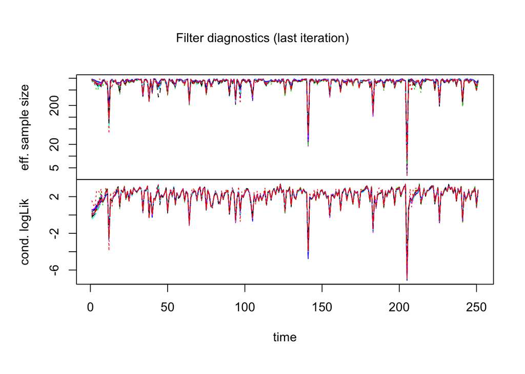

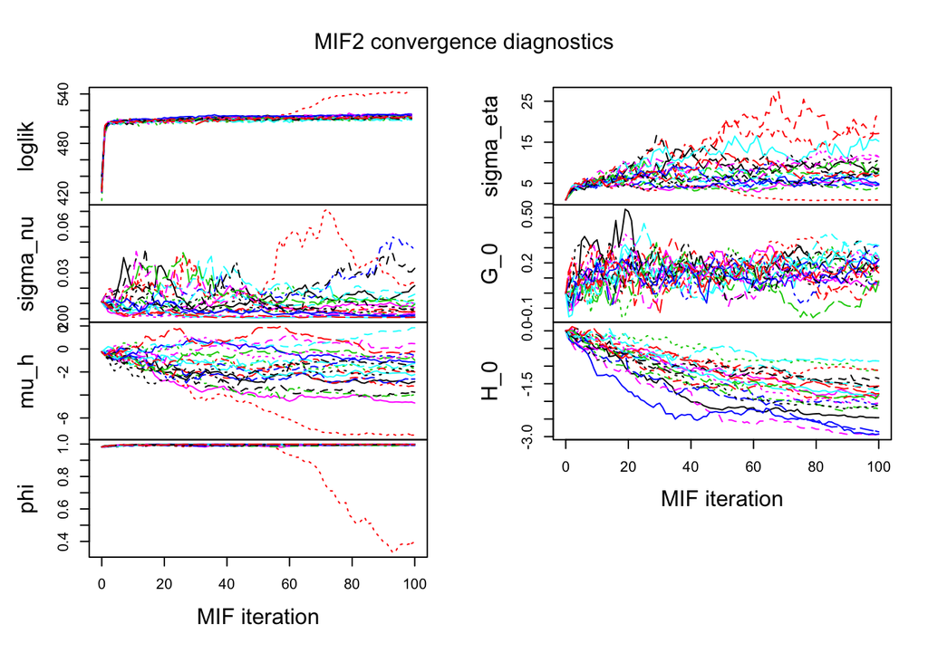

```r
plot(if1)
```

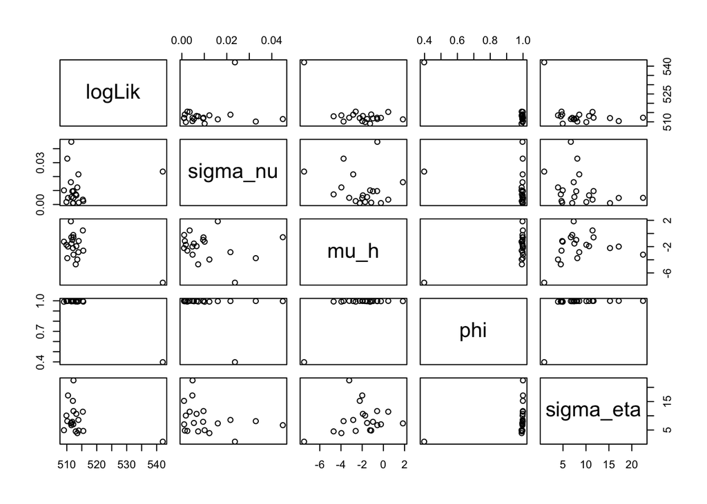

```r
pairs(~logLik+sigma_nu+mu_h+phi+sigma_eta,
      data=subset(r.if1,logLik>max(logLik)-500))
```

From the results above,

1. We could see that the largest logLikelihood is 542.0 for this POMP model.
2. The likelihood converges quickly, with an estimated mean of 513.7, and once it converged, it becomes quitely stable. $H_0$ are not shrinkage, however, since $H_0$ is just the starting point of the POMP model, there are naturally large fluctuations and we don’t need to pay more attention on this phenomenon. Almost all parameters are not convergent, however, if you observe carefully, we could find that they all stay in very small range of intervals. Considering about the small sample size, we could conclude that this result is basically satisfied.

## 4.5 Likelihood maximization using randomized starting values

Finally, we search on likelihood starting randomly throughout a large box. We could obtain the similar results and conclusions as what in the local search method above. We think that maybe we could refine the parameters box and then run the alogrithms to optimize the results.

```r
tsla_box <- rbind(
  sigma_nu=c(0.005,0.05),
  mu_h    =c(-1,0),
  phi = c(0.95,0.99),
  sigma_eta = c(0.5,1),
  G_0 = c(-2,2),
  H_0 = c(-1,1)
)

stew(file=sprintf("box_eval-%d.rda",run_level),{ t.box <- system.time({
  if.box <- foreach(i=1:tsla_global,
                    .packages='pomp',.combine=c) %dopar% mif2(if1[[1]],
                                                              params=apply(tsla_box,1,function(x)runif(1,x)))
  L.box <- foreach(i=1:tsla_global,
                   .packages='pomp',.combine=rbind) %dopar% { logmeanexp(replicate(tsla_eval, logLik(pfilter(
                     tsla.filt,params=coef(if.box[[i]]),Np=tsla_Np))),
                     se=TRUE)
                   } })
},seed=290860873,kind="L'Ecuyer")
r.box <- data.frame(logLik=L.box[,1],logLik_se=L.box[,2],
                    t(sapply(if.box,coef)))
if(run_level>1) write.table(r.box,file="TSLA.csv",
                            append=TRUE,col.names=FALSE,row.names=FALSE)
summary(r.box$logLik,digits=5)
```

```
##    Min. 1st Qu.  Median    Mean 3rd Qu.    Max.
##   502.5   510.4   513.3   514.8   514.9   541.1
```

```r
r.box[which.max(r.box$logLik),]
```

```
##             logLik logLik_se   sigma_nu      mu_h       phi sigma_eta
## result.11 541.1146 0.1306042 0.03139986 -7.453165 0.4908952 0.9498469
##                 G_0       H_0
## result.11 0.2242531 -1.289617
```

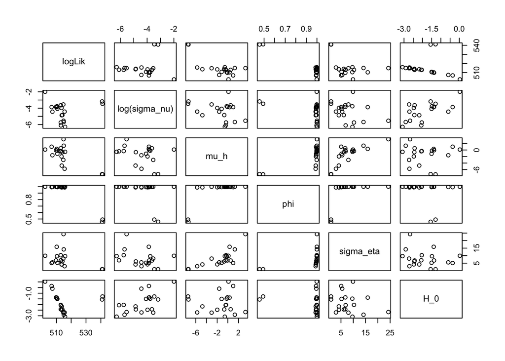

```r
pairs(~logLik+log(sigma_nu)+mu_h+phi+sigma_eta+H_0,
      data=subset(r.box,logLik>max(logLik)-500))
```

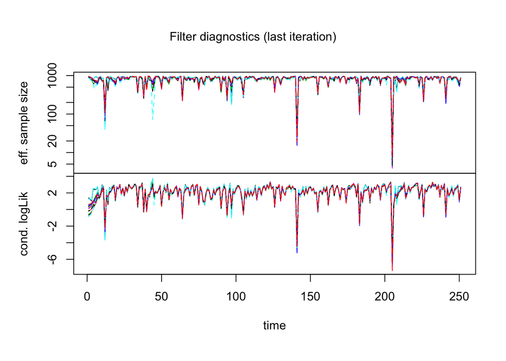

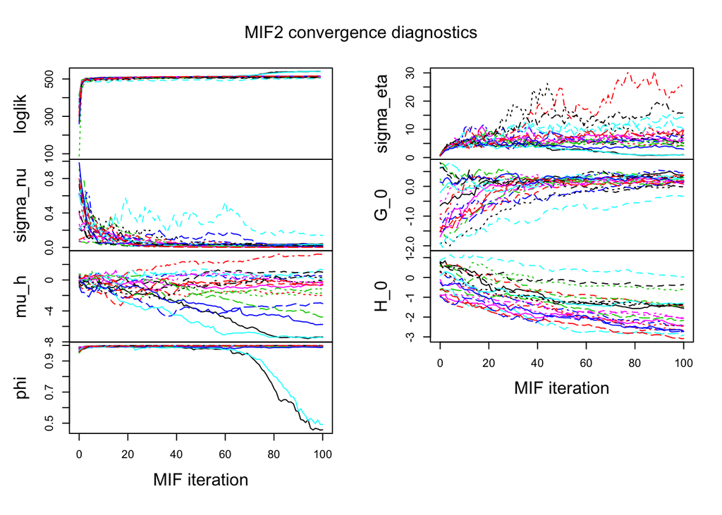

```r
plot(if.box)
```

# 5 GRACH model

## 5.1 Model Description

The generalized ARCH model, known as GARCH(p,q), has the form $Y_n$ = $\epsilon_n$$\sqrt{V_n}$,

where $V_n$ = $\alpha_0$ + $\sum_{j=1}^{p}\alpha_j$$Y_{n-j}^2$ + $\sum_{k=1}^{q}\beta_k$$V_{n-k}$ and $\epsilon_{1:N}$ is white noise.

## 5.2 Building the GARCH(1,1) model

```r
library(tseries)
require(fGarch)
garch11 <- garchFit(~garch(1,1), data = tsla_dm, cond.dist = c("norm"), include.mean = FALSE, algorithm = c("nlminb"), hessian = c("ropt"))
```

[output not shown]

[output cut: 28 more lines]

[output not shown]

```r
summary(garch11)
```

```
##
## Title:
##  GARCH Modelling
##
## Call:
##  garchFit(formula = ~garch(1, 1), data = tsla_dm, cond.dist = c("norm"),
##     include.mean = FALSE, algorithm = c("nlminb"), hessian = c("ropt"))
##
## Mean and Variance Equation:
##  data ~ garch(1, 1)
## <environment: 0x7fda388bf548>
##  [data = tsla_dm]
##
## Conditional Distribution:
##  norm
##
## Coefficient(s):
##      omega      alpha1       beta1
## 2.4813e-05  1.0000e-08  9.7300e-01
##
## Std. Errors:
##  based on Hessian
##
## Error Analysis:
##         Estimate  Std. Error  t value Pr(>|t|)
## omega  2.481e-05   1.104e-05    2.248   0.0246 *
## alpha1 1.000e-08          NA       NA       NA
## beta1  9.730e-01          NA       NA       NA
## ---
## Signif. codes:  0 '***' 0.001 '**' 0.01 '*' 0.05 '.' 0.1 ' ' 1
##
## Log Likelihood:
##  517.0769    normalized:  2.060067
##
## Description:
##  Mon May  4 13:36:48 2020 by user:
##
##
## Standardised Residuals Tests:
##                                 Statistic p-Value
##  Jarque-Bera Test   R    Chi^2  388.5955  0
##  Shapiro-Wilk Test  R    W      0.9137103 7.339919e-11
##  Ljung-Box Test     R    Q(10)  9.327889  0.5012941
##  Ljung-Box Test     R    Q(15)  13.87553  0.5349893
##  Ljung-Box Test     R    Q(20)  14.97234  0.7779881
##  Ljung-Box Test     R^2  Q(10)  3.862239  0.9533477
##  Ljung-Box Test     R^2  Q(15)  4.959775  0.9924615
##  Ljung-Box Test     R^2  Q(20)  6.900504  0.9969988
##  LM Arch Test       R    TR^2   5.257037  0.948838
##
## Information Criterion Statistics:
##       AIC       BIC       SIC      HQIC
## -4.096230 -4.054093 -4.096511 -4.079273
```

## 5.3 Check the 95% interval for the GARCH(1,1) model

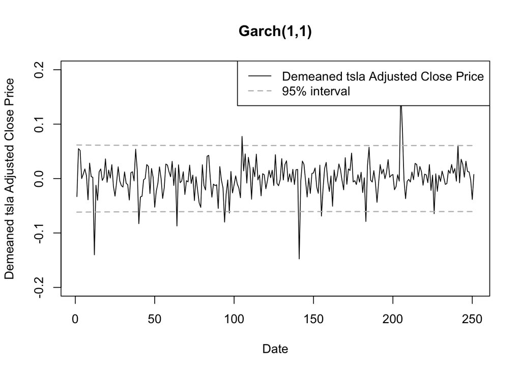

```r
t11 = garch11@sigma.t
plot(tsla_dm, ylim = c(-0.2,0.2), ylab = 'Demeaned tsla Adjusted Close Price', xlab = 'Date', type = 'l', main = 'Garch(1,1)', lwd = 1)
lines(-2*t11, lty=2, col='grey', lwd = 1.5)
lines(2*t11, lty=2, col='grey', lwd = 1.5)
legend('topright', c('Demeaned tsla Adjusted Close Price','95% interval'), col = c('black','grey'), lty = c(1,2), lwd = c(1,1.5))
```

## 5.4 QQ-plot

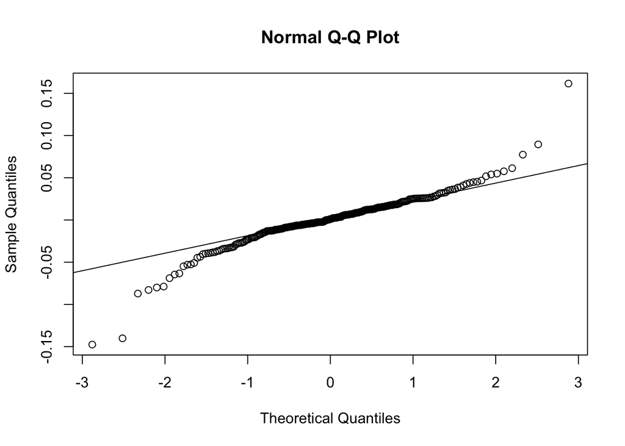

```r
qqnorm(tsla_dm)
qqline(tsla_dm)
```

From the results above, we could obtain that the logLikelihood for GARCH(1,1) is 517.1, which is smaller than it in POMP model.

# 6 Conclusion

# 7 Reference

1. Stochastic Volatility of the SPX500 Index (“https://ionides.github.io/531w16/final_project/Project14/Final.html”)
2. Financial Volatility of Google Stock (“https://ionides.github.io/531w18/final_project/1/final.html”)
3. Investigation on Financial Volatility of NASDAQ (“https://ionides.github.io/531w18/final_project/2/final.html”)
4. Stochastic Volatility of Nasdaq index (“https://ionides.github.io/531w18/final_project/16/final.html”)
5. Analysis of SP500 Volatility (“https://ionides.github.io/531w18/final_project/19/final.html”)
6. Time Series Analysis of Nintendo stock price (“https://ionides.github.io/531w18/final_project/27/final.html”)
7. Analyzing the Volatility of Bitcoin Market Price (“https://ionides.github.io/531w18/final_project/35/final.html”)
8. Case study: POMP modeling to investigate financial volatility (“https://ionides.github.io/531w20/14/notes14.pdf”)
9. Can log likelihood function be positive- Cross Validated (“https://www.google.com/url?sa=t&rct=j&q=&esrc=s&source=web&cd=3&cad=rja&uact=8&ved=2ahUKEwixwL_hp47pAhVXYs0KHbFJAcMQFjACegQIDBAG&url=https%3A%2F%2Fstats.stackexchange.com%2Fquestions%2F319859%2Fcan-log-likelihood-funcion-be-positive&usg=AOvVaw2a1dWxy4kc55mNfj0CAyuE”)
10. 2019 USA Economy (“https://www.google.com/url?sa=t&rct=j&q=&esrc=s&source=web&cd=1&cad=rja&uact=8&ved=2ahUKEwjJ9buvqY7pAhXQKs0KHZRABQsQFjAAegQIBBAB&url=https%3A%2F%2Fwww.reuters.com%2Farticle%2Fwrapup-us-2019-economy-trump-target-0131-idCNKBS1ZU092&usg=AOvVaw2-j-JOqzvQUlTRh-x4qCV4”)
11. Tesla 2019 Financial Report (“https://www.google.com/url?sa=t&rct=j&q=&esrc=s&source=web&cd=1&cad=rja&uact=8&ved=2ahUKEwiM5ObgqY7pAhWaK80KHblbDb0QFjAAegQIARAB&url=https%3A%2F%2Fauto.sina.cn%2Fnews%2Fhy%2F2020-02-06%2Fdetail-iimxxste9398111.d.html&usg=AOvVaw3ZDGExRI4Jnyi9UtXrMQUE”)